# 705604096_stats101c_hw3

Jade Gregory 705604096

2023-10-23

## Question 1

```r
winetrain <- read.csv("WineTrain.csv")
winetest <- read.csv("WineTest.csv")
winetrain$Class <- as.factor(winetrain$Class)
winetrain$Wine.Color <- as.factor(winetrain$Wine.Color)
winetest$Class <- as.factor(winetest$Class)
winetest$Wine.Color <- as.factor(winetest$Wine.Color)
head(winetest)
```

```
##   X Wine.Color fixed.acidity volatile.acidity citric.acid residual.sugar
## 1 1          R           8.6             0.45        0.31            2.6
## 2 2          W           6.9             0.25        0.24            3.6
## 3 3          W           8.1             0.20        0.28            0.9
## 4 4          R           7.8             0.56        0.19            2.1
## 5 5          W           6.3             0.35        0.30            5.7
## 6 6          W           6.0             0.27        0.15            1.5
##   chlorides free.sulfur.dioxide total.sulfur.dioxide density   pH sulphates
## 1     0.086                  21                   50 0.99820 3.37      0.91
## 2     0.057                  13                   85 0.99420 2.99      0.48
## 3     0.023                  49                   87 0.99062 2.92      0.36
## 4     0.081                  15                  105 0.99620 3.33      0.54
## 5     0.035                   8                   97 0.99270 3.27      0.41
## 6     0.056                  35                  128 0.99360 3.12      0.45
##   alcohol Class
## 1     9.9  Good
## 2     9.5   Bad
## 3    11.1  Good
## 4     9.5   Bad
## 5    11.0  Good
## 6     8.8  Good
```

```r
head(winetrain)
```

```
##   X Wine.Color fixed.acidity volatile.acidity citric.acid residual.sugar
## 1 1          W           7.3             0.23        0.41           14.6
## 2 2          R          10.0             0.32        0.59            2.2
## 3 3          W           6.2             0.27        0.43            7.8
## 4 4          W           6.6             0.25        0.32            5.6
## 5 5          W           6.9             0.24        0.39            1.3
## 6 6          W           7.1             0.23        0.39            1.6
##   chlorides free.sulfur.dioxide total.sulfur.dioxide density   pH sulphates
## 1     0.048                  73                  223 0.99863 3.16      0.71
## 2     0.077                   3                   15 0.99940 3.20      0.78
## 3     0.056                  48                  244 0.99560 3.10      0.51
## 4     0.039                  15                   68 0.99163 2.96      0.52
## 5     0.063                  18                  136 0.99280 3.31      0.48
## 6     0.032                  12                   65 0.98980 3.25      0.40
##   alcohol Class
## 1     9.4   Bad
## 2     9.6   Bad
## 3     9.0   Bad
## 4    11.1  Good
## 5    10.4  Good
## 6    12.7  Good
```

```r
# wine training data glm model
winetrainglm <- glm(Class ~ . - X - Class, data = winetrain, family = binomial())
summary(winetrainglm)
```

```
##
## Call:
## glm(formula = Class ~ . - X - Class, family = binomial(), data = winetrain)
##
## Coefficients:
##                        Estimate Std. Error z value Pr(>|z|)
## (Intercept)           2.022e+02  7.014e+01   2.883 0.003938 **
## Wine.ColorW          -2.540e-01  2.691e-01  -0.944 0.345231
## fixed.acidity         2.212e-01  7.336e-02   3.015 0.002569 **
## volatile.acidity     -1.280e+00  3.656e-01  -3.500 0.000465 ***
## citric.acid           3.216e-01  3.445e-01   0.933 0.350576
## residual.sugar        9.878e-02  2.803e-02   3.524 0.000425 ***
## chlorides            -3.847e+00  1.601e+00  -2.403 0.016246 *
## free.sulfur.dioxide   8.239e-03  3.407e-03   2.418 0.015596 *
## total.sulfur.dioxide -3.128e-03  1.446e-03  -2.164 0.030486 *
## density              -2.127e+02  7.106e+01  -2.993 0.002759 **
## pH                    1.674e+00  4.141e-01   4.042 5.30e-05 ***
## sulphates             1.433e+00  3.492e-01   4.105 4.05e-05 ***
## alcohol               1.810e-01  8.768e-02   2.064 0.038999 *
## ---
## Signif. codes:  0 '***' 0.001 '**' 0.01 '*' 0.05 '.' 0.1 ' ' 1
##
## (Dispersion parameter for binomial family taken to be 1)
##
##     Null deviance: 3881.2  on 2799  degrees of freedom
## Residual deviance: 3603.1  on 2787  degrees of freedom
## AIC: 3629.1
##
## Number of Fisher Scoring iterations: 4
```

```r
# wine training data confusion matrix
winetrainprob <- predict(winetrainglm, data = winetrain, type = "response")
wtrainpredl <- rep("Good", length(winetrainprob))
wtrainpredl[winetrainprob <= 0.5] <- "Bad"
table(wtrainpredl, winetrain$Class)
```

```
##
## wtrainpredl Bad Good
##        Bad  937  520
##        Good 481  862
```

```r
# misclassification rate
mean(wtrainpredl != winetrain$Class)
```

```
## [1] 0.3575
```

The misclassification rate of the wine training data for the glm model is 35.75%.

```r
# wine testing data confusion matrix
winetestprob <- predict(winetrainglm, data = winetrain, newdata = winetest, type = "response")
wtestpredl <- rep("Good", length(winetestprob))
wtestpredl[winetestprob <= 0.5] <- "Bad"
table(wtestpredl, winetest$Class)
```

```
##
## wtestpredl Bad Good
##       Bad  427  212
##       Good 205  356
```

```r
# misclassification rate
mean(wtestpredl != winetest$Class)
```

```
## [1] 0.3475
```

The misclassification rate of the wine testing data for the glm model is 34.75%.

```r
# lda model
winelda <- lda(Class ~ . - X - Class, data = winetrain)
winelda
```

```
## Call:
## lda(Class ~ . - X - Class, data = winetrain)
##
## Prior probabilities of groups:
##       Bad      Good
## 0.5064286 0.4935714
##
## Group means:
##      Wine.ColorW fixed.acidity volatile.acidity citric.acid residual.sugar
## Bad    0.7320169      7.263047        0.3584908   0.3123836       5.640197
## Good   0.7858177      7.161505        0.3189146   0.3273444       5.176773
##       chlorides free.sulfur.dioxide total.sulfur.dioxide   density       pH
## Bad  0.06012623            30.29055             117.7475 0.9951660 3.210063
## Good 0.05074096            30.90630             113.7218 0.9940833 3.227366
##      sulphates  alcohol
## Bad  0.5253597 10.20609
## Good 0.5359624 10.82847
##
## Coefficients of linear discriminants:
##                                LD1
## Wine.ColorW          -3.849040e-01
## fixed.acidity         3.535272e-01
## volatile.acidity     -1.977917e+00
## citric.acid           5.221028e-01
## residual.sugar        1.572735e-01
## chlorides            -5.317770e+00
## free.sulfur.dioxide   1.265154e-02
## total.sulfur.dioxide -4.921709e-03
## density              -3.427890e+02
## pH                    2.645963e+00
## sulphates             2.225004e+00
## alcohol               2.805697e-01
```

```r
library(caret)
# training data confusion matrix
t1 <- table(predict(winelda)$class, winetrain$Class)
print(confusionMatrix(t1))
```

```
## Confusion Matrix and Statistics
##
##
##        Bad Good
##   Bad  940  526
##   Good 478  856
##
##                Accuracy : 0.6414
##                  95% CI : (0.6233, 0.6592)
##     No Information Rate : 0.5064
##     P-Value [Acc > NIR] : <2e-16
##
##                   Kappa : 0.2824
##
##  Mcnemar's Test P-Value : 0.138
##
##             Sensitivity : 0.6629
##             Specificity : 0.6194
##          Pos Pred Value : 0.6412
##          Neg Pred Value : 0.6417
##              Prevalence : 0.5064
##          Detection Rate : 0.3357
##    Detection Prevalence : 0.5236
##       Balanced Accuracy : 0.6411
##
##        'Positive' Class : Bad
##
```

```r
# training data misclassification rate
winepred1 <- predict(winelda, winetrain)
wine.classify <- winepred1$class
wine.classperc <- mean(wine.classify != winetrain$Class)
wine.classperc
```

```
## [1] 0.3585714
```

The misclassification rate for the wine training data for the lda model is 35.857%.

```r
# testing data confusion matrix
t2 <- table(predict(winelda, winetest)$class, winetest$Class)
print(confusionMatrix(t2))
```

```
## Confusion Matrix and Statistics
##
##
##        Bad Good
##   Bad  428  215
##   Good 204  353
##
##                Accuracy : 0.6508
##                  95% CI : (0.6231, 0.6778)
##     No Information Rate : 0.5267
##     P-Value [Acc > NIR] : <2e-16
##
##                   Kappa : 0.299
##
##  Mcnemar's Test P-Value : 0.6252
##
##             Sensitivity : 0.6772
##             Specificity : 0.6215
##          Pos Pred Value : 0.6656
##          Neg Pred Value : 0.6338
##              Prevalence : 0.5267
##          Detection Rate : 0.3567
##    Detection Prevalence : 0.5358
##       Balanced Accuracy : 0.6493
##
##        'Positive' Class : Bad
##
```

```r
# misclassification rate for testing data
winepred2 <- predict(winelda, winetest)
wine.classify2 <- winepred2$class
wine.classperc2 <- mean(wine.classify2 != winetest$Class)
wine.classperc2
```

```
## [1] 0.3491667
```

The misclassification rate for wine testing data for the lda model is 34.916%.

```r
# qda model
wineqda <- qda(Class ~ . - X - Class, data = winetrain, method = "mle")
wineqda
```

```
## Call:
## qda(Class ~ . - X - Class, data = winetrain, method = "mle")
##
## Prior probabilities of groups:
##       Bad      Good
## 0.5064286 0.4935714
##
## Group means:
##      Wine.ColorW fixed.acidity volatile.acidity citric.acid residual.sugar
## Bad    0.7320169      7.263047        0.3584908   0.3123836       5.640197
## Good   0.7858177      7.161505        0.3189146   0.3273444       5.176773
##       chlorides free.sulfur.dioxide total.sulfur.dioxide   density       pH
## Bad  0.06012623            30.29055             117.7475 0.9951660 3.210063
## Good 0.05074096            30.90630             113.7218 0.9940833 3.227366
##      sulphates  alcohol
## Bad  0.5253597 10.20609
## Good 0.5359624 10.82847
```

```r
# training confusion matrix
wqdapred <- predict(wineqda)$class
table(wqdapred, winetrain$Class)
```

```
##
## wqdapred  Bad Good
##     Bad   718  307
##     Good  700 1075
```

```r
# misclassification rate
mean(winetrain$Class != wqdapred)
```

```
## [1] 0.3596429
```

The misclassification rate for the qda model of the training data is 35.96%.

```r
# testing confusion matrix
wqdapred2 <- predict(wineqda, winetest)$class
table(wqdapred2, winetest$Class)
```

```
##
## wqdapred2 Bad Good
##      Bad  318  144
##      Good 314  424
```

```r
# misclassification rate
mean(winetest$Class != wqdapred2)
```

```
## [1] 0.3816667
```

The misclassification rate for the qda model for the testing data is 38.16%.

```r
library(class)
```

```r
set.seed(113355)
winetestX <- winetest[-c(1,14)]
winetrainX <- winetrain[-c(1,14)]
winetestY <- winetest$Class
winetrainY <- winetrain$Class
winetrainX[-c(1)] <- scale(winetrainX[-c(1)])
winetestX[, -1] <- scale(winetestX[, -1])
winetrainX$Wine.Color <- as.numeric(winetrainX$Wine.Color)
winetestX$Wine.Color <- as.numeric(winetestX$Wine.Color)
wineknn <- knn(winetrainX, winetestX, winetrainY, k = 25)
table(wineknn, winetestY)
```

```
##        winetestY
## wineknn Bad Good
##    Bad  405  194
##    Good 227  374
```

```r
mean(wineknn != winetestY)
```

```
## [1] 0.3508333
```

The misclassification rate for the knn model is 35.08%.

## Question 2

```r
olives <- read.csv("Olives.csv")
olives$region <- as.factor(olives$region)
olives$area <- as.factor(olives$area)
set.seed(1234567)
i = 1:dim(olives)[1]
i.train <- sample(i, 400, replace = FALSE)
O.train <- olives[i.train,]
O.test <- olives[-i.train,]
O.testY <- O.test$region
```

```r
library(e1071)
```

```r
olive.nb <- naiveBayes(region ~ . - X - region, data = O.train)
olive.nb
```

```
##
## Naive Bayes Classifier for Discrete Predictors
##
## Call:
## naiveBayes.default(x = X, y = Y, laplace = laplace)
##
## A-priori probabilities:
## Y
##      1      2      3
## 0.5725 0.1800 0.2475
##
## Conditional probabilities:
##    area
## Y    Calabria  Coast-Sardinia  East-Liguria  Inland-Sardinia  North-Apulia
##   1 0.18340611      0.00000000    0.00000000       0.00000000    0.05240175
##   2 0.00000000      0.31944444    0.00000000       0.68055556    0.00000000
##   3 0.00000000      0.00000000    0.33333333       0.00000000    0.00000000
##    area
## Y      Sicily  South-Apulia     Umbria  West-Liguria
##   1 0.12227074    0.64192140 0.00000000    0.00000000
##   2 0.00000000    0.00000000 0.00000000    0.00000000
##   3 0.00000000    0.00000000 0.31313131    0.35353535
##
##    palmitic
## Y       [,1]      [,2]
##   1 1341.371 144.25424
##   2 1109.458  39.70558
##   3 1100.303  78.35730
##
##    palmitoleic
## Y        [,1]     [,2]
##   1 156.32751 49.72011
##   2  96.72222 14.11843
##   3  83.30303 23.24161
##
##    stearic
## Y       [,1]     [,2]
##   1 227.1179 38.96838
##   2 226.2778 16.77626
##   3 232.8788 38.98515
```

[output cut: 15 more lines]

```
##   1 38.21834  8.265093
##   2 26.90278  5.259893
##   3 21.25253 17.182302
##
##    arachidic
## Y       [,1]     [,2]
##   1 62.91703 11.34070
##   2 73.05556 11.74361
##   3 36.68687 30.69955
##
##    eicosenoic
## Y        [,1]      [,2]
##   1 26.820961 8.6042776
##   2  1.888889 0.7229742
##   3  1.909091 0.7297037
```

```r
olive.fit <- predict(olive.nb, O.test)
table(olive.fit, O.test$region)
```

```
##
## olive.fit  1  2  3
##         1 89  0  0
##         2  0 26  0
##         3  5  0 52
```

```r
mean(olive.fit != O.testY)
```

```
## [1] 0.02906977
```

The misclassification rate of our testing data is 2.9%.

```r
oliveslda <- lda(region ~ . - X - region, data = O.train)
t_olive <- table(predict(oliveslda, O.test)$class, O.test$region)
print(confusionMatrix(t_olive))
```

```
## Confusion Matrix and Statistics
##
##
##      1  2  3
##   1 94  0  0
##   2  0 26  0
##   3  0  0 52
##
## Overall Statistics
##
##                Accuracy : 1
##                  95% CI : (0.9788, 1)
##     No Information Rate : 0.5465
##     P-Value [Acc > NIR] : < 2.2e-16
##
##                   Kappa : 1
##
##  Mcnemar's Test P-Value : NA
##
## Statistics by Class:
##
##                      Class: 1 Class: 2 Class: 3
## Sensitivity            1.0000   1.0000   1.0000
## Specificity            1.0000   1.0000   1.0000
## Pos Pred Value         1.0000   1.0000   1.0000
## Neg Pred Value         1.0000   1.0000   1.0000
## Prevalence             0.5465   0.1512   0.3023
## Detection Rate         0.5465   0.1512   0.3023
## Detection Prevalence   0.5465   0.1512   0.3023
## Balanced Accuracy      1.0000   1.0000   1.0000
```

```r
olivespred <- predict(oliveslda, O.test)
olives.classify <- olivespred$class
mean(olives.classify != O.test$region)
```

```
## [1] 0
```

The misclassification rate is 0%.

```r
oliveslda
```

```
## Call:
## lda(region ~ . - X - region, data = O.train)
##
## Prior probabilities of groups:
##      1      2      3
## 0.5725 0.1800 0.2475
##
## Group means:
##   areaCoast-Sardinia  areaEast-Liguria  areaInland-Sardinia  areaNorth-Apulia
## 1           0.0000000         0.0000000            0.0000000        0.05240175
## 2           0.3194444         0.0000000            0.6805556        0.00000000
## 3           0.0000000         0.3333333            0.0000000        0.00000000
##   areaSicily  areaSouth-Apulia  areaUmbria  areaWest-Liguria  palmitic
## 1   0.1222707         0.6419214   0.0000000         0.0000000 1341.371
## 2   0.0000000         0.0000000   0.0000000         0.0000000 1109.458
## 3   0.0000000         0.0000000   0.3131313         0.3535354 1100.303
##   palmitoleic  stearic    oleic  linoleic linolenic arachidic eicosenoic
## 1   156.32751 227.1179 7085.026 1040.4847  38.21834  62.91703  26.820961
## 2    96.72222 226.2778 7272.375 1193.1111  26.90278  73.05556   1.888889
## 3    83.30303 232.8788 7780.768  735.1414  21.25253  36.68687   1.909091
##
## Coefficients of linear discriminants:
##                               LD1          LD2
## areaCoast-Sardinia   -0.651828788  1.278422491
## areaEast-Liguria     -0.134797838  0.502428409
## areaInland-Sardinia   0.651828788 -1.278422491
## areaNorth-Apulia     -2.396916072 -0.949239757
## areaSicily           -1.436300054  0.592584527
## areaSouth-Apulia     -3.507927484  2.089896331
## areaUmbria            1.229762200 -1.167751246
## areaWest-Liguria     -1.026227244  0.610415424
## palmitic              0.007108048  0.005477706
## palmitoleic           0.005271761  0.005050268
## stearic               0.010372433  0.002062706
## oleic                 0.010913925  0.004842669
## linoleic              0.015054351 -0.004535588
## linolenic            -0.051294858  0.007803169
## arachidic             0.038397315 -0.027860988
## eicosenoic           -0.094789705 -0.046556254
##
## Proportion of trace:
##    LD1    LD2
## 0.7628 0.2372
```

The proportion of tracee for LD1 is 0.7628, and the proportion of trace for LD2 is 0.2372.

```r
library(ggplot2)
```

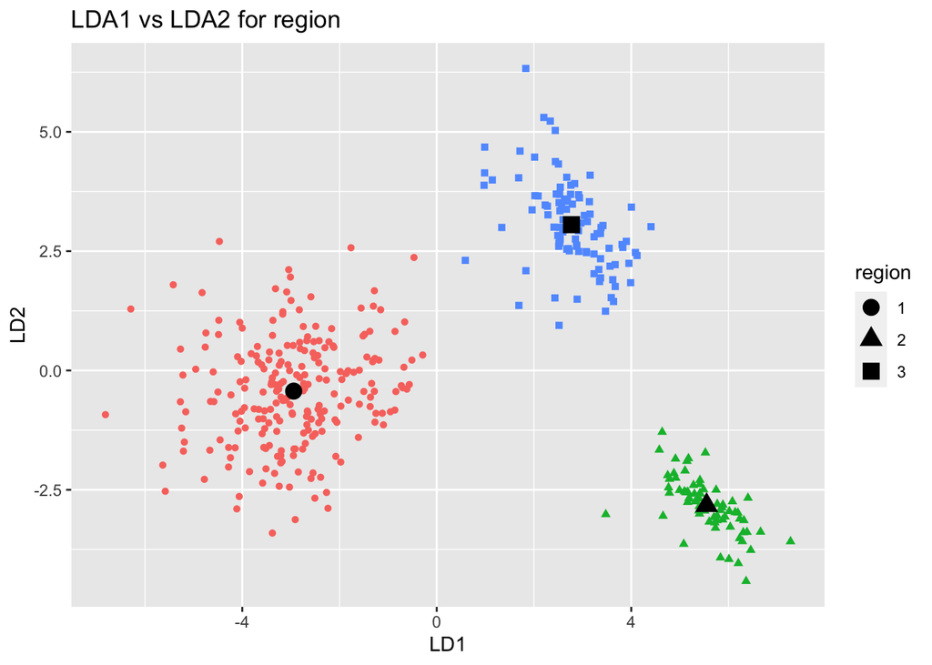

```r
LD1 <- predict(oliveslda)$x[,1]
LD2 <- predict(oliveslda)$x[,2]
centroids <- aggregate(data = O.train, cbind(LD1, LD2) ~ region, mean)
cenplot <- ggplot(data = O.train, aes(LD1, LD2, colour = region, shape = region)) + geom_point()
cenplot + ggtitle("LDA1 vs LDA2 for region") + geom_point(size = 1) + geom_point(data = centroids, size = 4, colour = "black")
```

```r
O.train$area <- as.numeric(O.train$area)
O.test$area <- as.numeric(O.test$area)
# qda model
olivesqda <- qda(region ~ . - X - region, data = O.train, method = "mle")
# testing confusion matrix
oqdapred <- predict(olivesqda, O.test)$class
table(oqdapred, O.test$region)
```

```
##
## oqdapred  1  2  3
##        1 94  0  1
##        2  0 26  0
##        3  0  0 51
```

```r
# misclassification rate
mean(O.test$region != oqdapred)
```

```
## [1] 0.005813953
```

The misclassification rate is 0.58%.

```r
summary(olivesqda)
```

```
##         Length Class  Mode
## prior     3    -none- numeric
## counts    3    -none- numeric
## means    27    -none- numeric
## scaling 243    -none- numeric
## ldet      3    -none- numeric
## lev       3    -none- character
## N         1    -none- numeric
## call      4    -none- call
## terms     3    terms  call
## xlevels   0    -none- list
```

This is the summary of our QDA model.